# ENVI 504 Data Project: Bacterial Growth Curves

Anna Vietmeier

7/26/2021

## Introduction

Abandoned mine drainage (AMD) is the result of abandoned mining operations. AMD is high in sulfuric acid, heavy metals, and metalloids. Treatment of AMD can be carried out via passive remediation systems. Passive remediation systems consist of large settling ponds that promote the biogeochemical precipitation of AMD contaminants. Since these systems are open to the environment, they are naturally colonized by microbial populations. Microbes within these populations metabolically impact the remediation process, both positively and negatively. Isolate AV1 from the Boyce park passive remediation system pond 1 has been identified to positively impact iron remediation and negatively impact manganese remediation. Characterization of this microbial isolate is important to understand more about this novel isolate and understand how it can impact AMD remediation. Characterization of isolate AV1 includes understanding how the isolate grows under different conditions. This is facilitated via growing AV1 in rich media such as R2A as well as minimal media M63.

## Methods

Isolate AV1 was grown in the shaker at 30C with either R2A pH 4.0 or M63 media. M63 minimal media was supplemented with an additional carbon source, either lactate or acetate. All conditions were grown at 30C. Different subculture ratios were used for the rich media to mirror those that had been manually obtained in the lab. Data for this experiment was collected using a 96-well plate and plate reader. Controls for the experiments included sterile R2A pH 4.0 and M63 supplemented with either lactate or acetate to be used as a blank and remove background noise.

## Results

All **Figure A’s** show each individual growth curve for the given condition, in total, each condition was tested 8 times. All **Figure B’s** show the average and standard deviation of the 8 replicates. All **Figure C’s** show the average exponential phase of growth for the replicates and also show an exponential trend line to determine the doubling time.

### Growth Condition 1: AV1 R2A pH 4.0 30C 1:25 subculture

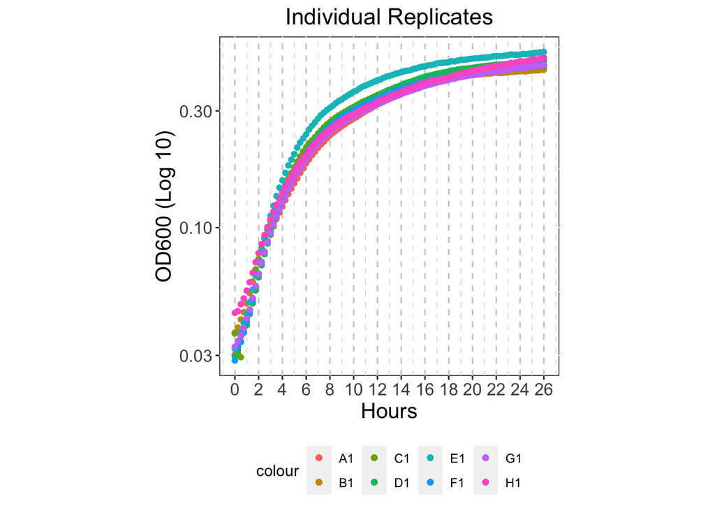

**Figure 1A.** Shows the growth curve experiment for condition 1 for 8-individual replicates.

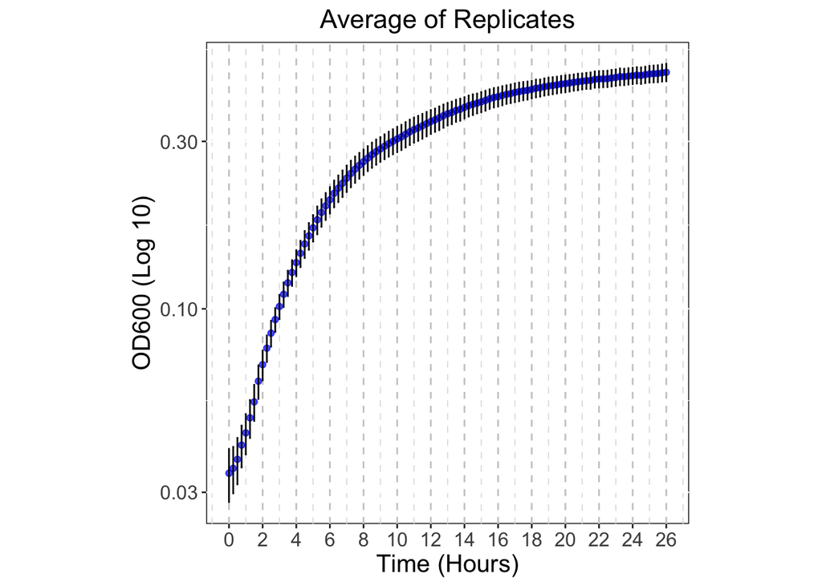

**Figure 1B.** Shows the growth curve experiment for condition 1 as the average of 8-individual replicates and the standard deviation of the replicates.

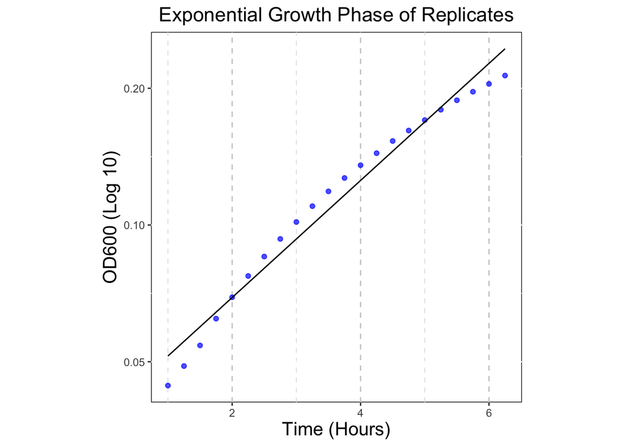

**Figure 1C.** Shows the exponential phase of growth from the growth curve experiment for condition 1 as the average of 8-individual replicates. An exponential trend line has been fitted to the data.